# Meridian Backtester — Results

Comparison of three signal sources over the 2010–2024 window using the Jan 2010 S&P 100 (OEX) universe, daily bars, 5 bps slippage each side.

Regime splits: **Pre-COVID** 2010-01-01 → 2020-02-29 · **Post-COVID** 2020-03-01 → 2024-12-31

*Generated by `backtest/run_quant.py`. Data from yfinance with `auto_adjust=True`.*

```
Loaded: ['quant', 'vader']
```

## Data Availability

| Signal | Status |
| --- | --- |
| Quant | ✓ results available |
| VADER | ✓ results available |
| FinBERT | ✗ not yet (see TODO.md) |
| SPY benchmark | ✓ results available |

## Full-Window Metrics (2010–2024)

'—' indicates the strategy has not been run yet or produced no trades. Sharpe SE uses the Mertens/Lo (2002) iid approximation; true SE is wider for strategies with autocorrelated returns.

|  | Quant | Vader | Finbert |
| --- | --- | --- | --- |
| Sharpe | 0.760 | 0.586 | — |
| Sharpe SE | 0.018 | 0.018 | — |
| Excess Sharpe (vs SPY) | -0.078 | -0.202 | — |
| Max Drawdown | 31.9% | 41.1% | — |
| Hit Rate | 58.1% | 62.3% | — |
| Avg Win ($) | 47,913 | 53,954 | — |
| Avg Loss ($) | -22,756 | -29,046 | — |
| Win/Loss Ratio | 2.11 | 1.86 | — |
| Avg Hold (days) | 209.8 | 540.0 | — |
| # Trades | 215 | 69 | — |
| % Time in Market | 98.4% | 99.9% | — |
| Total Return | 534.2% | 217.4% | — |
| CAGR | 13.1% | 8.6% | — |

## Equity Curves (Rebased to 100)

All strategies start at 100 regardless of initial cash so absolute returns are directly comparable. The red dotted line marks the COVID regime split (2020-03-01).

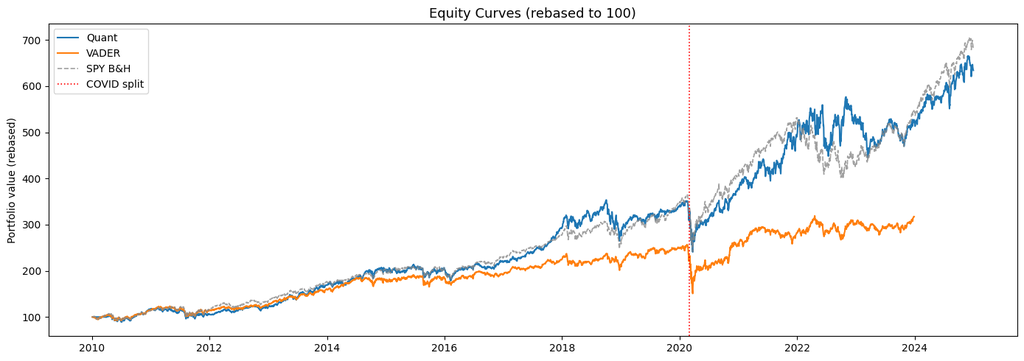

## Drawdown

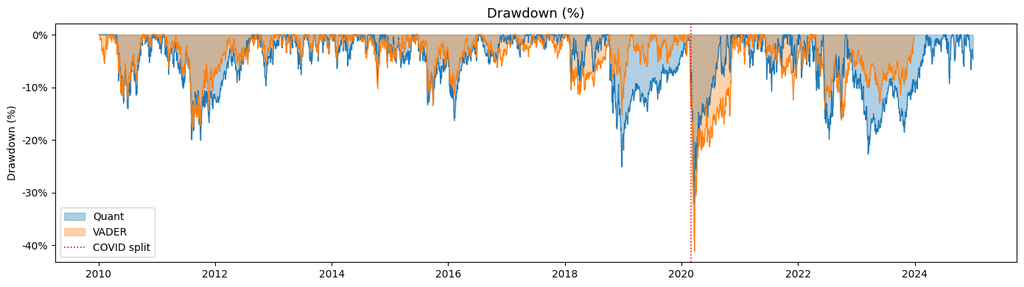

## Regime Split: Sharpe Ratio

Pre-COVID (2010–Feb 2020) vs Post-COVID (Mar 2020–2024). A strategy with consistent Sharpe across both halves is more robust than one that only looks good in one regime.

| Strategy | Full (2010–2024) | Pre-COVID (2010–Feb 2020) | Post-COVID (Mar 2020–2024) |
| --- | --- | --- | --- |
| Quant | 0.7596 | 0.7804 | 0.7154 |
| Vader | 0.5857 | 0.6343 | 0.4921 |
| Finbert | NaN | NaN | NaN |

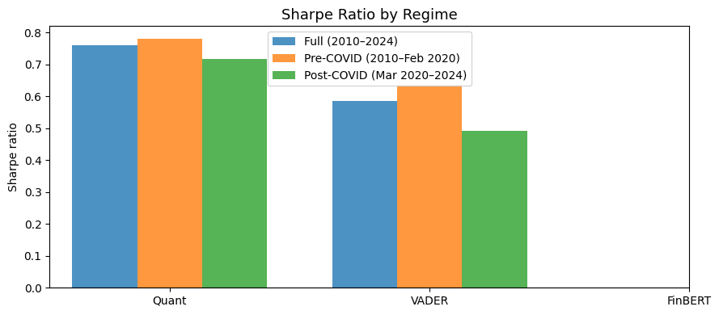

## Trade Statistics

Hit rate, average holding period, and trade count per strategy. Quant (momentum + mean-reversion) typically shows shorter holding periods than sentiment-based strategies.

| Signal | # Trades | Hit Rate | Avg Win ($) | Avg Loss ($) | W/L Ratio | Avg Hold (d) |
| --- | --- | --- | --- | --- | --- | --- |
| Quant | 215 | 58.1% | 47,913 | -22,756 | 2.11 | 209.8 |
| VADER | 69 | 62.3% | 53,954 | -29,046 | 1.86 | 540.0 |

## Pre-COVID vs Post-COVID — Full Metrics

```
### Full (2010–2024)
```

|  | Quant | Vader | Finbert |
| --- | --- | --- | --- |
| Sharpe | 0.760 | 0.586 | — |
| Sharpe SE | 0.018 | 0.018 | — |
| Excess Sharpe (vs SPY) | -0.078 | -0.202 | — |
| Max Drawdown | 31.9% | 41.1% | — |
| Hit Rate | 58.1% | 62.3% | — |
| Avg Win ($) | 47,913 | 53,954 | — |
| Avg Loss ($) | -22,756 | -29,046 | — |
| Win/Loss Ratio | 2.11 | 1.86 | — |
| Avg Hold (days) | 209.8 | 540.0 | — |
| # Trades | 215 | 69 | — |
| % Time in Market | 98.4% | 99.9% | — |
| Total Return | 534.2% | 217.4% | — |
| CAGR | 13.1% | 8.6% | — |

```
### Pre-COVID (2010–Feb 2020)
```

|  | Quant | Vader | Finbert |
| --- | --- | --- | --- |
| Sharpe | 0.780 | 0.634 | — |
| Sharpe SE | 0.023 | 0.022 | — |
| Excess Sharpe (vs SPY) | -0.069 | -0.215 | — |
| Max Drawdown | 25.1% | 17.9% | — |
| Hit Rate | 61.9% | 66.7% | — |
| Avg Win ($) | 32,852 | 36,640 | — |
| Avg Loss ($) | -12,633 | -19,273 | — |
| Win/Loss Ratio | 2.60 | 1.90 | — |
| Avg Hold (days) | 219.1 | 531.6 | — |
| # Trades | 139 | 51 | — |
| % Time in Market | 97.7% | 99.9% | — |
| Total Return | 209.3% | 121.0% | — |
| CAGR | 11.8% | 8.1% | — |

```
### Post-COVID (Mar 2020–2024)
```

|  | Quant | Vader | Finbert |
| --- | --- | --- | --- |
| Sharpe | 0.715 | 0.492 | — |
| Sharpe SE | 0.032 | 0.034 | — |
| Excess Sharpe (vs SPY) | -0.097 | -0.191 | — |
| Max Drawdown | 26.8% | 35.3% | — |
| Hit Rate | 51.3% | 50.0% | — |
| Avg Win ($) | 81,126 | 119,359 | — |
| Avg Loss ($) | -37,256 | -47,507 | — |
| Win/Loss Ratio | 2.18 | 2.51 | — |
| Avg Hold (days) | 192.7 | 563.7 | — |
| # Trades | 76 | 18 | — |
| % Time in Market | 100.0% | 100.0% | — |
| Total Return | 94.3% | 37.5% | — |
| CAGR | 14.7% | 8.7% | — |

## Honest Disclosures

1. **Daily bars from yfinance** — `auto_adjust=True` for total-return semantics. Known caveats: adjusted-close handling may differ for stocks with complex corporate actions; occasional gaps on illiquid/delisted names; dividend treatment varies. Spot-check accordingly.
2. **5 bps slippage assumption** is stylised; actual slippage varies by ticker liquidity. The 2010–2024 era is post-Reg-NMS and post-decimalization, making a single slippage assumption more defensible than spanning 2005–2007.
3. **Universe is S&P 100 (OEX) constituents as of Jan 2010, held constant.** A handful of names were acquired or delisted during 2010–2024. Post-event returns are recorded honestly: acquisitions at cash price, bankruptcies at −100%, no resurrection. This is the survivorship-bias-free universe.
4. **No commission model.** Modern retail brokers are commission-free. Pre-2019 retail commissions ($5–$10 per trade) are NOT modelled — disclose this when reporting pre-2019 returns. Institutional commissions (1–3 bps) are folded into the 5 bps slippage assumption.
5. **Sentiment data source: FNSPID (Dong et al. 2024).** VADER and FinBERT use the FNSPID academic news dataset ([arXiv:2402.06698](https://arxiv.org/abs/2402.06698), HuggingFace `Zihan1004/FNSPID`): 15.7M timestamp-aligned headlines for 4,775 S&P 500 companies, 1999–2023. **License: CC BY-NC 4.0** — this backtest is research/non-commercial use; a commercial product would require separate licensing.
6. **Window asymmetry: sentiment ends 2023-12-31.** FNSPID coverage stops at end of 2023 while yfinance bars extend through 2024-12-31. For apples-to-apples comparison in the full-window cell above, the quant curve should be sliced to 2023-12-31 when comparing against sentiment strategies. The pre-COVID window (2010–Feb 2020) is unaffected.
7. **FinBERT thresholds match the live bot** (`finbert_threshold=0.6`, `vader_threshold=0.35`, `min_count=2`, `min_consensus=0.6`) so the backtest measures the same decision boundary that ran in production.